# Rent

## Graphic

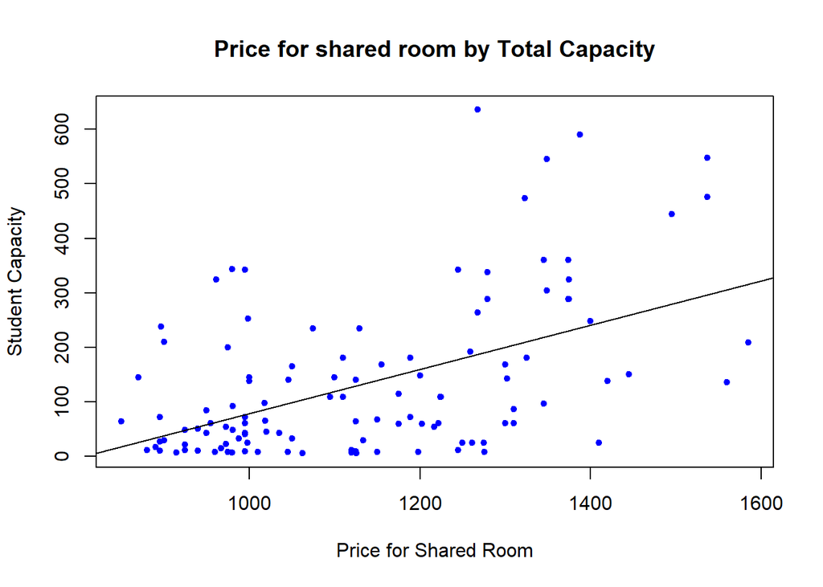

```r
# Use this R-chunk to...
# ...Create an interesting graphic using the Rent data set.
plot(Rent$Price, Rent$Capacity, main="Price for shared room by Total Capacity", xlab="Price for Shared Room", ylab="Student Capacity", col="blue", pch=20)
mylm <- lm(Capacity ~ Price, data = Rent)
abline(mylm)
```

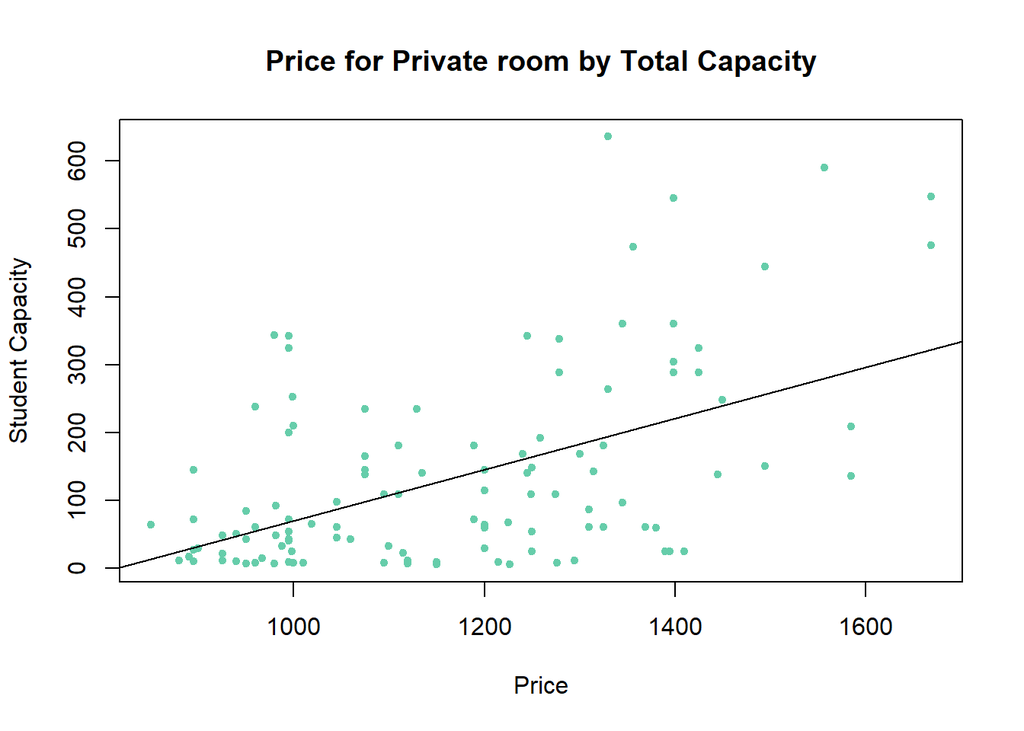

```r
plot(Rent$PrivateRoomPrice, Rent$Capacity, main="Price for Private room by Total Capacity", xlab="Price", ylab="Student Capacity", col="aquamarine3", pch=20)
mylm1 <- lm(Capacity ~ PrivateRoomPrice, data = Rent)
abline(mylm1)
```

These two scatterplots show price for shared rooms and private rooms against total complex capacity.

##Table

Sorry for the formatting here (or lack of) I was able to split the data but not sure really how to access and format the out but effectively.

```r
# Use this R-chunk to...
# ...compute and display a meaningful table of numerical summaries supporting your above graphic.
RentCopy <- Rent
rentsplit <- split(RentCopy$Price,cut(RentCopy$Capacity, 10))
rentsplit
```

```
## $`(4.37,68.1]`
##  [1] 1035.000  980.000 1062.500  972.500 1045.000  890.000  895.000 1202.500
##  [9]  995.000 1150.000       NA 1222.000  960.000 1019.000 1275.000  925.000
## [17]  998.000 1300.000 1310.000  925.000 1250.000 1216.667  988.000 1198.000
## [25]  995.000  995.000  850.000 1120.000  955.000 1261.667 1245.000  940.000
## [33]  940.000  925.000       NA  995.000  981.000 1020.000 1120.000  975.000
## [41] 1010.000  880.000 1120.000  950.000  995.000 1050.000 1133.333 1276.000
## [49]  900.000 1126.000  972.500 1175.000  915.000 1150.000 1125.000  895.000
## [57]  967.000 1125.000 1410.000 1198.000
##
## $`(68.1,131]`
##  [1] 1018.333 1345.000 1225.000 1310.000  950.000  895.000  995.000  981.000
##  [9] 1095.000 1224.000 1189.000       NA 1175.000 1110.000
##
## $`(131,194]`
##  [1] 1420.00 1445.00 1000.00 1000.00 1050.00 1100.00 1200.00 1325.00  870.00
## [10] 1189.00 1259.00 1125.00      NA 1046.25 1155.00 1110.00 1300.00      NA
## [19] 1302.50 1560.00
##
## $`(194,257]`
## [1]  999.0000  900.0000 1075.0000 1129.0000  975.0000  896.6667 1400.0000
## [8] 1585.0000
##
## $`(257,320]`
## [1] 1349.0 1375.0 1267.5 1374.0 1279.0
##
## $`(320,384]`
## [1]  980.0000  961.6667 1345.0000 1245.0000 1375.0000 1374.0000 1279.0000
## [8]  995.0000
##
## $`(384,447]`
## [1] 1495
##
## $`(447,510]`
## [1] 1323.000 1537.333
##
## $`(510,573]`
## [1] 1349.000 1537.333
##
## $`(573,637]`
## [1] 1267.5 1388.0
```

Here I split the data and cut it into 10 groups based on total capacity. I was hoping to be able to then display just the mean of each capacity range but couldn’t get that far with R this week. Regardless we can view each relative group of prices grouped by total student capacity and get a general idea of price (for a shared room) by using this output.